# Dimension Reduction

MGS3701 Data Mining, Spring 2025

Chad (Chungil Chae)

cchae@kean.edu

Tue, 27 May 2025

# Version and Document Information

# Learning Objectives

- The dimension of a dataset, which is the number of variables, must be reduced forthe data mining algorithms to operate efficiently.
- This process is part of the pilot/prototype phase of data mining and is done before deploying a model.
- We present and discuss several dimension reduction approaches:
  - 1. Incorporating domain knowledge to remove or combine categories,
  - 2. using data summaries to detect information overlap between variables (and remove or combine redundant variables or categories),
  - 3. using data conversion techniques such as converting categorical variables into numerical variables, and
  - 4. employing automated reduction techniques, such as principal components analysis (PCA), where a new set of variables (which are weighted averages of the original variables) is created.
- These new variables are uncorrelated and a small subset of them usually contains most of their combined information (hence, we can reduce dimension by using only a subset of the new variables).
- Finally, we mention data mining methods such as regression models and classification and regression trees, which can be used for removing redundant variables and for combining “similar” categories of categorical variables.

## SHORT VIDEO INTRODUCTION

[video not shown]

# Introduction

1. **Large Number of Variables:**
   - In data mining, large numbers of variables are common.
   - Initially small sets of variables often expand during data preparation.
2. **Expansion of Variables:**
   - Data preparation involves creating new derived variables. Examples include:
     - Dummies for categorical variables.
     - New forms of existing variables.
3. **Correlation and Model Impact:**
   - High correlation among subsets of variables is likely.
   - Including highly correlated variables can lead to:
     - Overfitting.
     - Reduced accuracy.
     - Reduced reliability.
4. **Computational Problems:**
   - Large numbers of variables can cause issues for:
     - Supervised algorithms.
     - Unsupervised algorithms.
     - Other computational processes aside from correlation concerns.
5. **Model Deployment Costs:**
   - Superfluous variables in models can lead to increased costs due to:
     - Collection.
     - Processing.

# Curse of Dimensionality

1. **Dimensionality of a Model:**
   - Definition: The number of predictors or input variables used by the model.
2. **Curse of Dimensionality:**
   - Definition: The problems caused by adding variables to multivariate data models.
   - As variables are added, the data space becomes increasingly sparse.
   - Classification and prediction models fail due to insufficient data across many variables.
3. **Exponential Increase in Difficulty:**
   - Difficulties increase exponentially with the addition of each variable.
   - Example for intuition:
     - A chessboard has 2 dimensions and 64 squares (choices).
     - Expanding the chessboard to a cube increases dimensions by 50% (from 2 to 3 dimensions).
     - Location options increase by 800%, to 512 (8 × 8 × 8).
4. **Statistical Distance and Noise:**
   - Proliferation of variables means nothing is close to anything else anymore.
   - Too much noise is added, making patterns and structures indiscernible.
5. **Big Data and Genomics:**
   - The problem is acute in Big Data applications.
   - Example: Genomics analysis might deal with values for thousands of different genes.
6. **Dimension Reduction:**
   - Key step in data mining to reduce dimensionality with minimal accuracy sacrifice.
   - In artificial intelligence literature:
     - Often referred to as factor selection or feature extraction.

# Practical Consideration

1. **Preference for Automated Methods:**
   - Data mining prefers automated methods over domain knowledge.
2. **Importance of Initial Data Exploration:**
   - Ensure variables measured are reasonable for the task at hand.
   - Integration of expert knowledge can lead to better results.
3. **Expert Knowledge Integration:**
   - Discussion with data provider (or user) is beneficial.
4. **Practical Considerations:**
   1. **Variable Importance:**
      - Which variables are most important for the task?
      - Which variables are likely to be useless?
   2. **Error-Prone Variables:**
      - Which variables are likely to contain much error?
   3. **Future Availability and Cost:**
      - Which variables will be available for future measurements?
      - What will it cost to measure them?
   4. **Measurability Before Outcome:**
      - Which variables can be measured before the outcome occurs?
5. **Example Scenario:**
   - Predicting the closing price of an ongoing online auction:
     - Cannot use the number of bids as a predictor because it is not known until the auction closes.

## Example: House Prices in Boston

1. **Boston Housing Example:**
   - Introduced in Chapter 3.
   - For each neighborhood, several variables are given.
2. **Example Variables:**
   - Crime rate.
   - Student/teacher ratio.
   - Median value of a housing unit in the neighborhood.
3. **First Record Example:**
   - Represents the first neighborhood.
   - Average per capita crime rate: 0.006.
   - 18% of the residential land zoned for lots over 25,000 ft².
   - 2.31% of the land devoted to nonretail business.
   - No border on the Charles River.
   - Additional details follow similarly.

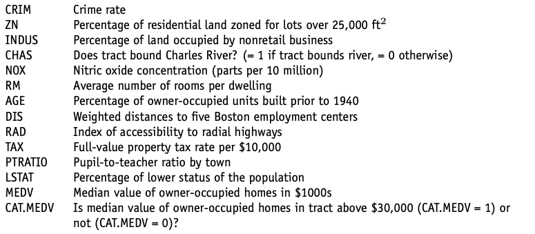

# Data Summaries

1. **Initial Step of Data Exploration:**
   - As seen in the chapter on data visualization.
   - Getting familiar with data and their characteristics using summaries and graphs.
   - This step’s importance cannot be overstated.
   - Better understanding leads to better modeling or mining results.
2. **Role of Numerical Summaries and Graphs:**
   - Helpful for data reduction.
   - Information conveyed can assist in:
     1. **Combining Categories:**
        - Combining categories of a categorical variable.
     2. **Variable Selection:**
        - Choosing variables to remove.
     3. **Information Overlap:**
        - Assessing the level of information overlap between variables.
3. **Strategies for Dimension Reduction:**
   - Before discussing these strategies, consider useful summaries and tools.

## Aggregation and Pivot Tables

# Correlation Analysis

1. **Large Datasets with Many Variables:**
   - Likely to serve as predictors.
   - Usually contain much overlap in information covered by the set of variables.
2. **Finding Redundancies:**
   - **Correlation Matrix:**
     - Shows all pairwise correlations between variables.
     - Identifies pairs with very strong (positive or negative) correlations.
       - Variables with high correlation have a lot of overlap in information.
       - Good candidates for data reduction by removing one of the variables.
3. **Avoiding Multicollinearity:**
   - Removing strongly correlated variables helps prevent multicollinearity problems.
     - **Definition:** Multicollinearity occurs when two or more predictors share the same linear relationship with the outcome variable.
     - R handles multicollinearity automatically in regression models.
4. **Detecting Variable Duplications:**
   - **Correlation Analysis:**
     - Useful for identifying duplicated variables in the dataset.
   - Duplications can occur when:
     - The same variable appears accidentally more than once under different names.
     - The dataset is merged from multiple sources.
     - The same phenomenon is measured in different units.
5. **Using Correlation Table Heatmaps:**
   - Heatmaps make identifying strong correlations easier.
   - Visual display of correlation matrix (as shown in Chapter 3).

# Reducing the Number of Categories in Categorical Variables

# Converting a Actegorical Variable to a Numerical Variable

1. **Categorical Variables Representing Intervals:**
   - Examples include age group or income bracket.
2. **Known Interval Values:**
   - If the values of the intervals are known:
     - **Example:** Category 2 represents the age interval 20–30.
3. **Replacing Categorical Values:**
   - Replace the categorical value with the mid-interval value.
     - **Example:** Replace “2” with “25” (mid-interval value for the age interval 20–30).
4. **Resulting Numerical Variable:**
   - The categorical variable becomes a numerical variable.
   - No longer requires multiple dummy variables.

# Principal Components Analysis

1. **Principal Components Analysis (PCA):**
   - A useful method for dimension reduction.
   - Especially valuable when the number of variables is large.
2. **Suitability:**
   - Effective when subsets of measurements are:
     - Measured on the same scale.
     - Highly correlated.
3. **Outcome of PCA:**
   - Provides a few variables (often as few as three).
   - These variables are weighted linear combinations of the original variables.
   - Retain the majority of the information from the full original set.
4. **Intended Use:**
   - PCA is designed for use with numerical variables.
5. **Alternative Methods for Categorical Variables:**
   - Other methods such as correspondence analysis are more suitable for categorical variables.

## Example: Breakfast Cereals

1. **Dataset Description:**
   - Data collected on the nutritional information and consumer rating of 77 breakfast cereals.
   - Consumer rating represents cereal “healthiness” for consumer information (not rated by consumers).
2. **Variables:**
   - Includes 13 numerical variables.
   - Focus is on reducing the dimensionality.

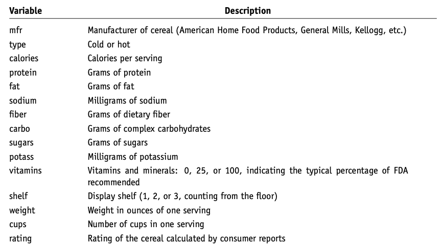

3. **Basis of Information:**
   - Information for each cereal is based on a bowl of cereal (constant volume) rather than a serving size (varies by weight).

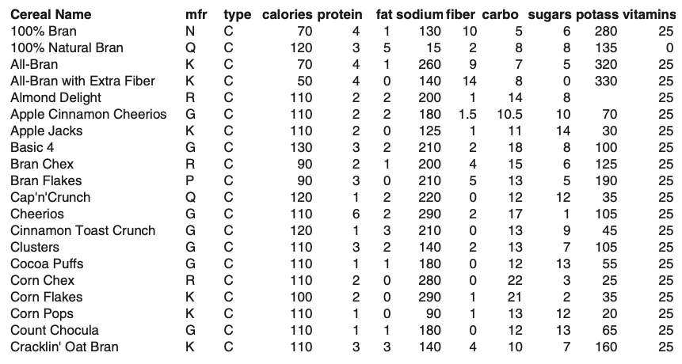

$$S =
\begin{bmatrix}
379.63 & -188.68 \\
-188.68 & 197.32
\end{bmatrix}$$

7. It can be seen that the two variables are strongly correlated with a negative correlation of

$$-0.69 = \frac{-188.68}{\sqrt{(379.63)(197.32)}}$$

1. **Total Variation and Co-variation:**
   - **Concept:**
     - 69% of the total variation in both variables is co-variation.
     - Variation in one variable is duplicated by similar variation in the other.
2. **Variable Reduction:**
   - **Objective:**
     - Reduce the number of variables while maximizing their unique contributions.
     - Possible to reduce two correlated variables to a single variable without much information loss.
3. **Principal Components Analysis (PCA):**
   - **Purpose:**
     - Find a linear combination of variables that contains most information.
     - Retain the majority of the variability (information).
   - **Example Calculation:**
     - Total variability: 379.63 (calories) + 197.32 (rating) = 577.
     - Calories account for 66% of total variability: $\frac{379.63}{577}$.
     - Rating accounts for 34% of total variability.
4. **Scatter Plot and Principal Components:**
   - **Figure 4.4:**
     - Scatter plot of rating vs. calories.
     - **z1-axis:** Direction with the largest variability (first principal component).
     - **z2-axis:** Perpendicular to z1 (second principal component).
   - z1: Line that captures the most variation.
   - Principal component: Line that minimizes the sum of squared perpendicular distances from the line.

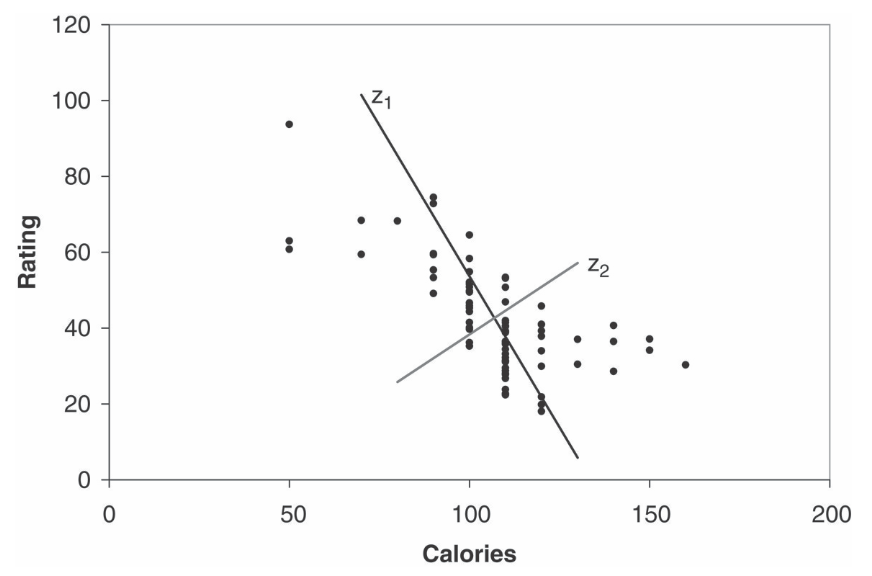

5. **Running PCA in R:**
   - **Function:** `prcomp()`
   - **Output:**
     - Rotation matrix (.rot): Weights for projections.
       - Weights for z1: (0.847, -0.532)
       - Weights for z2: (0.532, 0.847)
     - **Reallocated variance:**
       - z1 accounts for 86% of total variability.
       - z2 accounts for 14%.

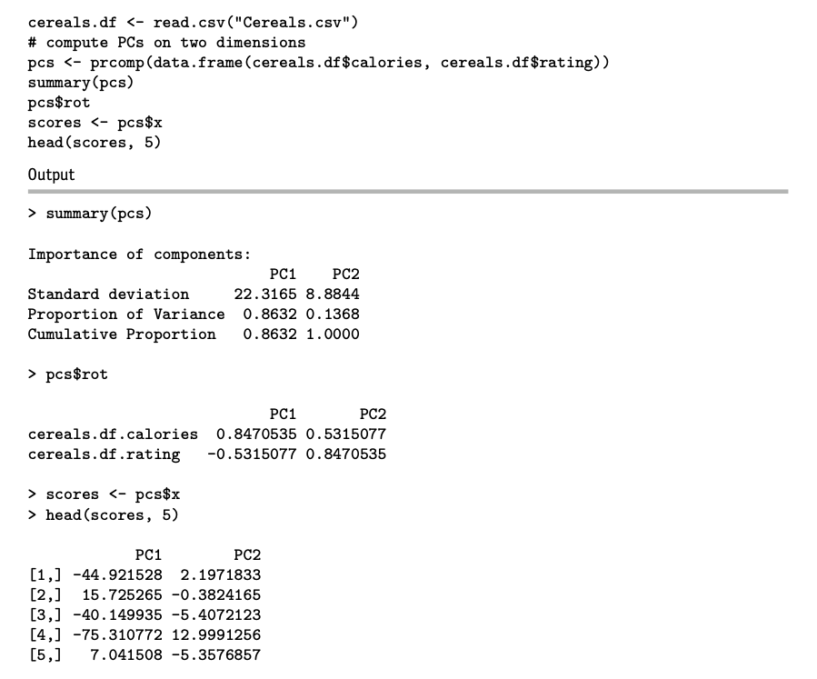

6. **Principal Component Scores:**
   - Projected values of calories and rating onto new axes (after subtracting means).
   - **Example Calculation:**
     - 100% Bran cereal with 70 calories and a rating of 68.4:
       - First score: $(0.847)(70 - 106.88) + (-0.532)(68.4 - 42.67) = -44.92$.
7. **Properties of New Variables:**
   - Means of z1 and z2 are zero (variables are mean-centered).
   - Sum of variances $\text{var}(z1) + \text{var}(z2)$ equals sum of original variances.
     - **Variances:**
       - var(z1) = 498
       - var(z2) = 79
     - z1 accounts for 86% of total variance.
8. **Conclusion:**
   - First principal component, z1, captures most variability.
   - Reasonable to use z1 to represent two original variables.
   - These concepts can be generalized to more than two variables.

## Principal Components

### Generalizing PCA Procedure for p > 2 Variables:

1. **Original Variables:**
   - Denote the original p variables by $X_1, X_2, \ldots, X_p$.
2. **New Variables** $Z_1, Z_2, \ldots, Z_p$:
   - PCA creates new variables as weighted averages of the original variables (after mean subtraction): $Z_i = a_{i,1}(X_1 - \overline{X_1}) + a_{i,2}(X_2 - \overline{X_2}) + \cdots + a_{i,p}(X_p - \overline{X_p}), \quad i = 1, \ldots, p$
   - Each pair of $Z$ variables has a correlation of 0 (they are uncorrelated).
   - Resulting $Z$ variables are ordered by their variance:
     - $Z_1$ has the largest variance.
     - $Z_p$ has the smallest variance.
3. **Principal Component Scores:**
   - Weights $a_{i,j}$ are computed by software and used to calculate the principal component scores.
4. **Advantages of Principal Components:**
   - Uncorrelated (correlation coefficient = 0).
   - Using principal components as predictors in regression models prevents multicollinearity issues.
5. **Example with Breakfast Cereal Dataset:**
   - Apply PCA to 13 numerical variables.
   - **Result (Table 4.11):**
     - First three components account for more than 96% of the total variation.
     - First two principal components capture 92.6% of the total variation.
   - Suggests capturing most variability with less than 25% of original dimensions.

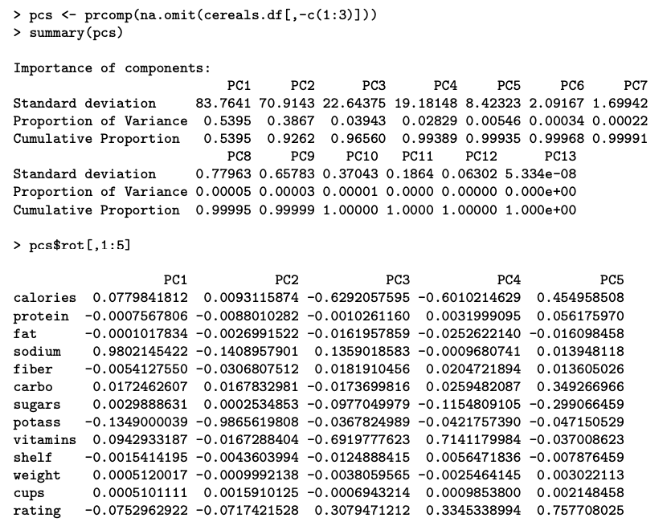

6. **Influence of Variable Scales:**
   - Results can be influenced by the scales of the variables.

## Normalizing the Data

1. **Understanding Data Structure with PCA:**
   - Examine the weights to see how the original variables contribute to the principal components.
   - **Example:**
     - First principal component is dominated by sodium content (highest weight).
     - Second principal component is dominated by potassium content.
     - Due to different units of measurement leading to dominance in total variance.
2. **Normalization:**
   - **Purpose:**
     - To give all variables equal importance in terms of variability.
   - **Method:**
     - Replace each original variable with a standardized version having unit variance.
     - Achieved by dividing each variable by its standard deviation.
   - **When to Normalize:**
     - Use normalization when variables are measured in different units.
     - Do not normalize if the variables’ scales reflect their importance and are common (e.g., dollars).
3. **Alternative to Normalization:**
   - Perform PCA on the correlation matrix instead of the covariance matrix.
   - Most software programs allow this choice.
4. **Example with Breakfast Cereal Data:**
   - Normalize 13 variables due to different scales.
   - Perform PCA on the correlation matrix.
   - **Output (Table 4.12):**
     - Need 7 principal components to account for more than 90% of the total variability.
     - First 2 principal components account for only 52% of the total variability.
     - Reducing to two variables would lose much information.

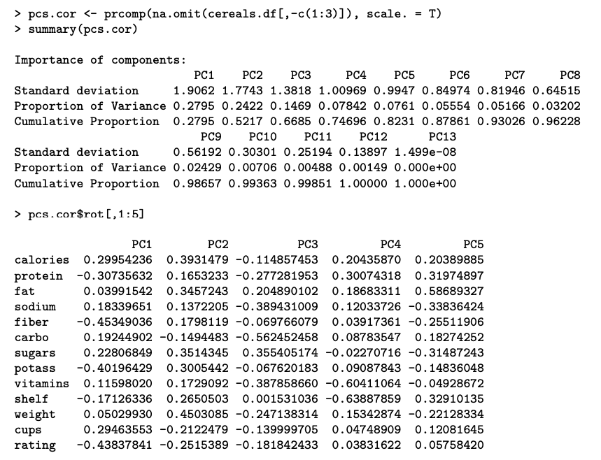

5. **Interpreting Principal Components:**
   - **First Principal Component:**
     - Measures the balance between calories and cups (positive weights) vs. protein, fiber, potassium, and consumer rating (negative weights).
     - High scores indicate high calories and amount per bowl but low protein and potassium.
     - Low consumer rating associated with high scores.
   - **Second Principal Component:**
     - Most affected by the weight of a serving.
   - **Third Principal Component:**
     - Most affected by carbohydrate content.
6. **Scatter Plot of Principal Component Scores:**
   - Useful when data can be reduced to two dimensions.
   - **Figure 4.5:**
     - Scatter plot of first vs. second principal component scores for breakfast cereals.
     - Observations labeled to reveal structure.
     - Moving from right to left: Cereals become less healthy.
     - Moving from bottom to top: Cereals get heavier.
     - Clusters of observations can be identified, such as children’s cereals in the middle-left part of the plot.

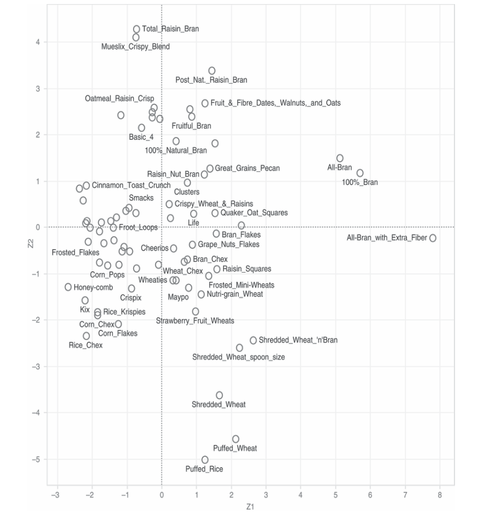

## Using Principal Components for Classification and Prediction

### PCA for Predictor Reduction in Supervised Learning:

1. **Goal:**
   - Reduce the number of variables while retaining predictive power.
2. **Procedure:**
   1. **Apply PCA to Predictors:**
      - Use the training data to perform PCA.
   2. **Determine Principal Components:**
      - Identify the number of principal components to retain.
   3. **Use Principal Scores as Predictors:**
      - Model will now use the reduced number of principal scores as predictors.
   4. **Validation Set:**
      - Compute principal scores for the validation set using weights from the training data.
      - Use these new principal scores as predictors for validation.
3. **Disadvantage:**
   - **Nonlinear Predictive Information:**
     - Using a subset of principal components might result in the loss of nonlinear relationships.
     - Example: Quadratic effects or interactions between predictors may not be captured.
   - **Reason:**
     - PCA produces linear transformations, capturing only linear relationships between the original variables.

# Dimension Reduction Using Regression Models

### Methods for Reducing the Number of Columns:

1. **Exploratory Methods:**
   - **Summary Statistics and Plots:**
     - Use summary statistics and data visualizations to understand and reduce data dimensions.
   - **Principal Components Analysis (PCA):**
     - PCA reduces dimensionality without considering the outcome variable.
2. **Informal Methods:**
   - Incorporate the relationship between predictors and the outcome variable.
   - **Example:**
     - Combining similar categories based on their similar behavior concerning the outcome variable.
3. **Regression Models for Dimension Reduction:**
   - Directly consider the predictive or classification task:
     - **Linear Regression:**
       - Used for prediction tasks (Refer to Chapter 6).
     - **Logistic Regression:**
       - Used for classification tasks (Refer to Chapter 10).
4. **Subset Selection Procedures:**
   - Algorithmically choose a subset of predictor variables from a larger set.
   - Details provided in the relevant chapters.
5. **Using Fitted Regression Models for Combining Categories:**
   - **Statistically Insignificant Coefficients:**
     - Categories with high p-values (not statistically significant) can be combined with the reference category.
     - Their distinction from the reference category has no significant effect on the outcome variable.
   - **Categories with Similar Coefficient Values:**
     - Categories with similar coefficients (and the same sign) can be combined.
     - Their effect on the outcome variable is similar.
6. **Example Illustration:**
   - Chapter 10 provides an example of predicting delayed flights, illustrating how regression models are used for dimension reduction.

# Dimension Reduction Using Classification and Regression Trees

### Classification and Regression Trees for Dimension Reduction:

1. **Purpose:**
   - Reduce the number of columns.
   - Combine categories of a categorical variable.
2. **Types of Trees:**
   - **Classification Trees:**
     - Used for classification tasks.
   - **Regression Trees:**
     - Used for prediction tasks.
3. **Method:**
   - Algorithm creates binary splits on the predictors to best classify/predict the outcome variable.
     - **Example:** Splitting age data into above/below age 30.
4. **Tree Diagram as a Tool:**
   - Determine important predictors:
     - Predictors that do not appear in the tree can be removed.
     - Categories that do not appear in the tree can be combined.

# House Keeping